# Developing Data Products - Assignment 4 Home Value Calculator

bjpotrat

8/19/2019

# Introduction

During the course of owning a home, owners often wonder how much a home remodel or addition will affect the value of their home.

With the “Home Value Calculator” App, users can upload a .csv file with information from Zillow.com, Redfin.com, or the user’s county parcel map.

Please note that the Load Data and Calculate button will load a test dataset.

# Initial Linear Model Applied and Data Cleaning

```r
Housedata <-read.csv(url('https://github.com/bjpotrat/DevDataProdsAsn4/raw/master/Housedata.csv'))
mdl.lm <- lm(BuildingValue~Beds+Bath50+Bath75+Bath100+Kitchens+TotalSqft+Fireplace+0, data= Housedata)
mdl.lm$coefficients
```

```
##       Beds     Bath50     Bath75    Bath100   Kitchens  TotalSqft
## -24734.540   2688.300  29676.687  31641.356 149115.115  61650.229
##  Fireplace
##   4203.434
```

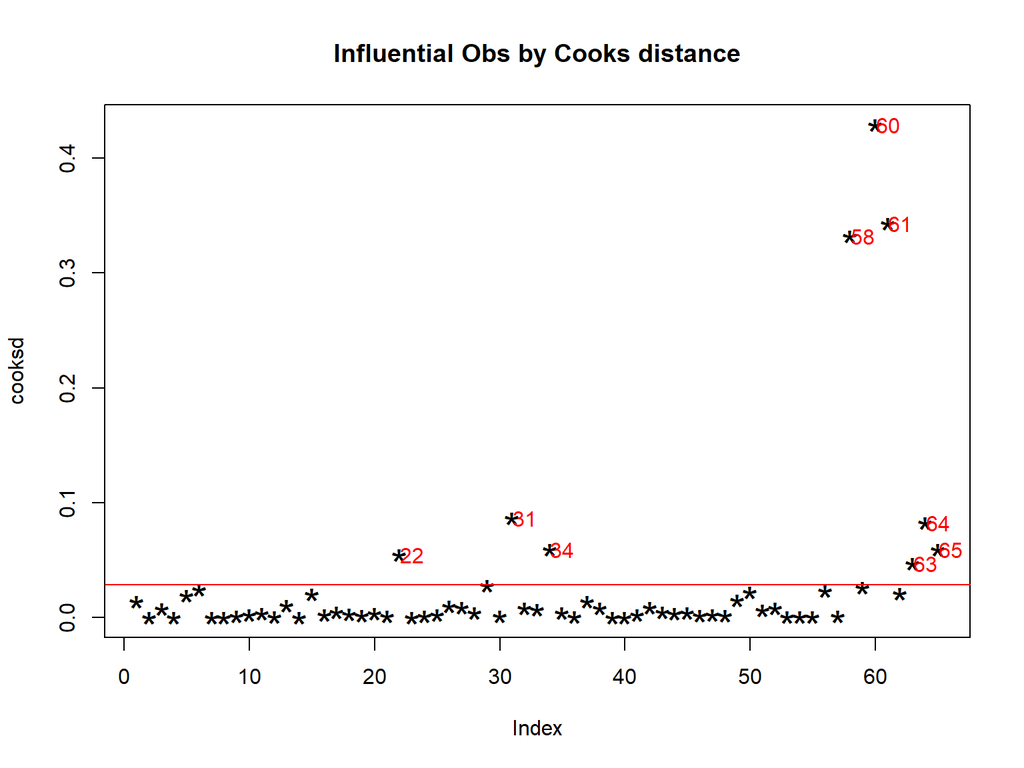

# Non-Negative Linear Model (NNLM)

Using NNLM, the coefficients of a linear model are forced to be possitive. The square footage of the home had to be scaled by a factor of 1000 to prevent abnormal wieght of it’s coefficient.

```r
library(NNLM)
Housedata.Clean<-Housedata[-influential,]
x<-Housedata.Clean[c("Beds","Bath50","Bath75","Bath100","Kitchens","TotalSqft","Fireplace")]
y<-Housedata.Clean["BuildingValue"]
mdl.NNLM <- nnlm(data.matrix(x),y, method = "lee", loss = "mse", alpha = 20)
round(mdl.NNLM$coefficients,2)
```

```
##           BuildingValue
## Beds            4732.65
## Bath50         11898.39
## Bath75         13292.13
## Bath100        18572.75
## Kitchens       29081.02
## TotalSqft      66462.73
## Fireplace       3331.95
```

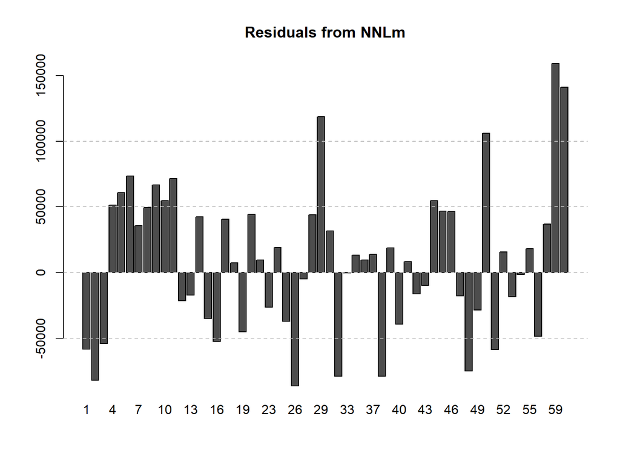

# Using the App

User Interaction:

- The user can load or calculate the by “clicking data and calclulate”.
- The user can select their home’s Id, which can be found on the House Data tab after the data has been loaded and calculated.
- The user can have the app calculate the estimated value of a house by clicking “Estimate Home Improvements”.
- The user can download and upload thier own data by using the download Homedata.csv and upload Homedata.csv button.

Output data tabs feature:

- A plot of the models estimated values verse the housedata.csv’s values.
- Your current home’s value base on “Your home’s ID”
- Your estimated home’s value based on the selected home parameters
- The model coefficients generated from NNLM
- The loaded House Data